# Course Notes | Text Mining with R | DataCamp

Peter

2019-05-30

# Senetiment Analysis

While word counts and visualizations suggest something about the content, we can do more. In this chapter, we move beyond word counts alone to analyze the sentiment or emotional valence of text.

## Sentiment dictionaries

**Bing dictionary**

```r
get_sentiments("bing")
```

```
## # A tibble: 6,788 x 2
##    word        sentiment
##    <chr>       <chr>
##  1 2-faced     negative
##  2 2-faces     negative
##  3 a+          positive
##  4 abnormal    negative
##  5 abolish     negative
##  6 abominable  negative
##  7 abominably  negative
##  8 abominate   negative
##  9 abomination negative
## 10 abort       negative
## # … with 6,778 more rows
```

```r
get_sentiments("bing") %>%
  count(sentiment)
```

```
## # A tibble: 2 x 2
##   sentiment     n
##   <chr>     <int>
## 1 negative   4782
## 2 positive   2006
```

**Afinn dictionary**

```r
get_sentiments("afinn")
```

```
## # A tibble: 2,476 x 2
##    word       score
##    <chr>      <int>
##  1 abandon       -2
##  2 abandoned     -2
##  3 abandons      -2
##  4 abducted      -2
##  5 abduction     -2
##  6 abductions    -2
##  7 abhor         -3
##  8 abhorred      -3
##  9 abhorrent     -3
## 10 abhors        -3
## # … with 2,466 more rows
```

```r
get_sentiments("afinn") %>%
  summarise(
    min = min(score),
    max = max(score)
  )
```

```
## # A tibble: 1 x 2
##     min   max
##   <int> <int>
## 1    -5     5
```

**Loughran dictionary**

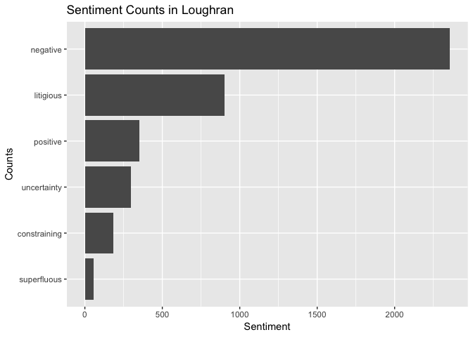

```r
sentiment_counts <- get_sentiments("loughran") %>%
  count(sentiment) %>%
  mutate(sentiment2 = fct_reorder(sentiment, n))

ggplot(sentiment_counts, aes(sentiment2, n)) +
  geom_col() +
  coord_flip() +
  labs(
    title = "Sentiment Counts in Loughran",
    x = "Counts",
    y = "Sentiment"
  )
```

## Counting the NRC sentiments

### Exercise

The fourth dictionary included with the tidytext package is the `nrc` dictionary. Let’s start our exploration with sentiment counts.

### Instructions

- I usually do this for you, but start with loading the `tidyverse` and `tidytext` packages.
- Count the number of words associated with each sentiment in `nrc`.
- Arrange the counts in descending order.

### script.R

```r
# Load the tidyverse and tidytext packages

library(tidyverse)
library(tidytext)

# Count the number of wrods associated with each sentiment in nrc
get_sentiments("nrc") %>%
  count(sentiment) %>%
  # Arrange the counts in descending roder
  arrange(desc(n))
```

```
## # A tibble: 10 x 2
##    sentiment        n
##    <chr>        <int>
##  1 negative      3324
##  2 positive      2312
##  3 fear          1476
##  4 anger         1247
##  5 trust         1231
##  6 sadness       1191
##  7 disgust       1058
##  8 anticipation   839
##  9 joy            689
## 10 surprise       534
```

## Visualizing the NRC sentiments

### Exercise

We’ve seen how visualizations can give us a better idea of patterns in data than counts alone. Let’s visualize the sentiments from the `nrc` dictionary. I’ve loaded the `tidyverse` and `tidytext` packages for you already.

### Instructions

- Extract the `nrc` dictionary, count the sentiments and reorder them by count to create a new factor column, `sentiment2`.
- Visualize `sentiment_counts` using the new sentiment factor column.
- Change the title to “Sentiment Counts in NRC”, x-axis to “Sentiment”, and y-axis to “Counts”.

### script.R

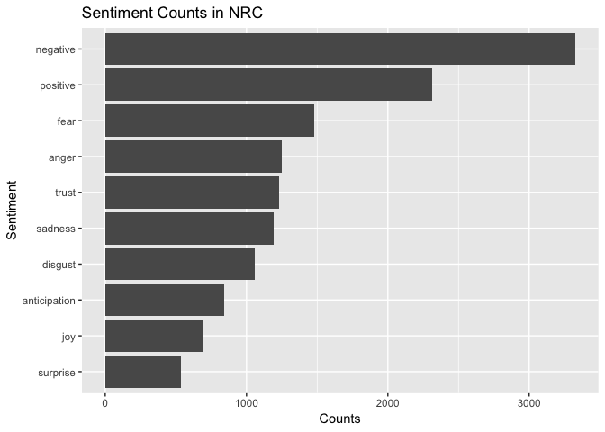

```r
# Pull in the nrc dictoinary, count the snetiments and reorder them by count
sentiment_counts <- get_sentiments("nrc") %>%
  count(sentiment) %>%
  mutate(sentiment2 = fct_reorder(sentiment, n))

# Visualize sentiment_counts using the new sentiment factor column
ggplot(sentiment_counts, aes(sentiment2, n)) +
  geom_col() +
  coord_flip() +
  # Change the title to "Sentiment Counts in NRC", x-axis to "Sentiment", and y-axis to "Counts"
  labs(
    title = "Sentiment Counts in NRC",
    x = "Sentiment",
    y ="Counts"
  )
```

## Appending dictionaries

**Using inner_join()**

```r
tidy_review %>%
  inner_join(get_sentiments("loughran"))
## Joining, by = "word"
## # A tibble: 3,960 x 6
##       id Date     Product                    Stars word      sentiment
##    <int> <chr>    <chr>                      <dbl> <chr>     <chr>
##  1     5 12/22/15 iRobot Roomba 650 for Pets     5 slow      negative
##  2     5 12/22/15 iRobot Roomba 650 for Pets     5 easily    positive
##  3     5 12/22/15 iRobot Roomba 650 for Pets     5 random    uncertainty
##  4     5 12/22/15 iRobot Roomba 650 for Pets     5 easy      positive
##  5     5 12/22/15 iRobot Roomba 650 for Pets     5 easy      positive
##  6     5 12/22/15 iRobot Roomba 650 for Pets     5 easy      positive
##  7     6 12/27/15 iRobot Roomba 650 for Pets     5 invention positive
##  8     7 8/17/15  iRobot Roomba 650 for Pets     1 damage    negative
##  9     7 8/17/15  iRobot Roomba 650 for Pets     1 damage    negative
## 10     7 8/17/15  iRobot Roomba 650 for Pets     1 justice   litigious
## # … with 3,950 more rows
```

**Counting sentiment**

```r
sentiment_review <- tidy_review %>%
  inner_join(get_sentiments("loughran"))
## Joining, by = "word"

sentiment_review %>%
  count(sentiment)
```

```
## # A tibble: 6 x 2
##   sentiment        n
##   <chr>        <int>
## 1 constraining   170
## 2 litigious       53
## 3 negative      1795
## 4 positive      1568
## 5 superfluous      1
## 6 uncertainty    373
```

```r
sentiment_review %>%
  count(word, sentiment) %>%
  arrange(desc(n))
```

```
## # A tibble: 598 x 3
##    word      sentiment       n
##    <chr>     <chr>       <int>
##  1 easy      positive      297
##  2 happy     positive      107
##  3 easier    positive       97
##  4 easily    positive       92
##  5 perfect   positive       87
##  6 random    uncertainty    81
##  7 impressed positive       77
##  8 excellent positive       58
##  9 trouble   negative       58
## 10 fantastic positive       56
## # … with 588 more rows
```

**Visualizing sentiment**

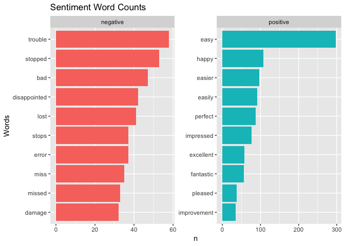

```r
sentiment_review2 <- sentiment_review %>%
  filter(sentiment %in% c("positive", "negative"))

word_counts <- sentiment_review2 %>%
  count(word, sentiment) %>%
  group_by(sentiment) %>%
  top_n(10, n) %>%
  ungroup() %>%
  mutate(word2 = fct_reorder(word, n))

ggplot(word_counts, aes(word2, n, fill = sentiment)) +
  geom_col(show.legend = FALSE) +
  facet_wrap(~ sentiment, scales = "free") +
  coord_flip() +
  labs(
    title = "Sentiment Word Counts",
    x = "Words"
  )
```

## Counting sentiment

### Exercise

The `tidy_twitter` dataset has been loaded for you. Let’s see what sort of sentiments are most prevalent in our Twitter data.

### Instructions

- Join `tidy_twitter` and the NRC sentiment dictionary.
- Count the sentiments in `sentiment_twitter`.
- Arrange the sentiment counts in descending order.

### script.R

```r
# Join tidy_twitter and the NRC sentiment dictionary
sentiment_twitter <- tidy_twitter %>%
  inner_join(get_sentiments("nrc"))
## Joining, by = "word"

# Count the sentiments in tidy_twitter
sentiment_twitter %>%
  count(sentiment) %>%
  # Arrange the sentiment counts in descending order
  arrange(desc(n))
```

```
## # A tibble: 10 x 2
##    sentiment        n
##    <chr>        <int>
##  1 positive      4415
##  2 trust         2873
##  3 negative      2747
##  4 anticipation  2124
##  5 joy           1480
##  6 sadness       1426
##  7 fear          1357
##  8 anger         1156
##  9 surprise       992
## 10 disgust        880
```

## Visualizing sentiment

### Exercise

Let’s explore which words are associated with each sentiment in our Twitter data.

### Instructions 1/2

Inner join `tidy_twitter` to the NRC dictionary and filter for positive, fear, and trust. Count by word and sentiment and keep only the top 10 of each sentiment. Create a factor called `word2` that has each word ordered by the count.

### script.R

```r
word_counts <- tidy_twitter %>%
  # Append the NRC dictionary and filter for positive, fear, and trust
  inner_join(get_sentiments("nrc")) %>%
  filter(sentiment %in% c("positive", "fear", "trust")) %>%
  # Count by word and sentiment and keep the top 10 of each
  count(word, sentiment) %>%
  group_by(sentiment) %>%
  top_n(10, n) %>%
  ungroup() %>%
  # Create a factor calles word2 that has each word ordered by the count
  mutate(word2 = fct_reorder(word, n))
## Joining, by = "word"
```

### Instructions 2/2

- Create a bar plot of the word counts colored by sentiment.
- Create a separate facet for each sentiment with free axes.
- Title the plot “Sentiment Word Counts” with “Words” for the x-axis.

### script.R

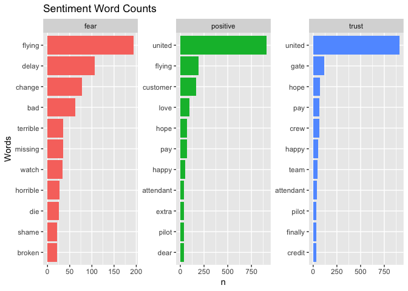

```r
# Create a bar plot out of the word counts colored by sentiment
ggplot(word_counts, aes(word2, n, fill = sentiment)) +
  geom_col(show.legend = FALSE) +
  # Create a separate facet for each sentiment with free axes
  facet_wrap(~ sentiment, scales = "free") +
  coord_flip() +
  # Title the plot "Sentiment Word Counts" with "Words" for the x-axis
  labs(
    title = "Sentiment Word Counts",
    x = "Words"
  )
```

## Improving sentiment analysis

**Count sentiment by rating**

```r
tidy_review %>%
  inner_join(get_sentiments("bing")) %>%
  count(Stars, sentiment)
## Joining, by = "word"
## # A tibble: 10 x 3
##    Stars sentiment     n
##    <dbl> <chr>     <int>
##  1     1 negative    381
##  2     1 positive    241
##  3     2 negative    384
##  4     2 positive    247
##  5     3 negative    485
##  6     3 positive    432
##  7     4 negative    984
##  8     4 positive    973
##  9     5 negative   3705
## 10     5 positive   5083
```

**Using spread()**

```r
tidy_review %>%
  inner_join(get_sentiments("bing")) %>%
  count(Stars, sentiment) %>%
  spread(sentiment, n)
## Joining, by = "word"
## # A tibble: 5 x 3
##   Stars negative positive
##   <dbl>    <int>    <int>
## 1     1      381      241
## 2     2      384      247
## 3     3      485      432
## 4     4      984      973
## 5     5     3705     5083
```

**Computing overall sentiment**

```r
tidy_review %>%
  inner_join(get_sentiments("bing")) %>%
  count(Stars, sentiment) %>%
  spread(sentiment, n) %>%
  mutate(overall_sentiment = positive - negative)
## Joining, by = "word"
## # A tibble: 5 x 4
##   Stars negative positive overall_sentiment
##   <dbl>    <int>    <int>             <int>
## 1     1      381      241              -140
## 2     2      384      247              -137
## 3     3      485      432               -53
## 4     4      984      973               -11
## 5     5     3705     5083              1378
```

**Visualize sentiment by rating**

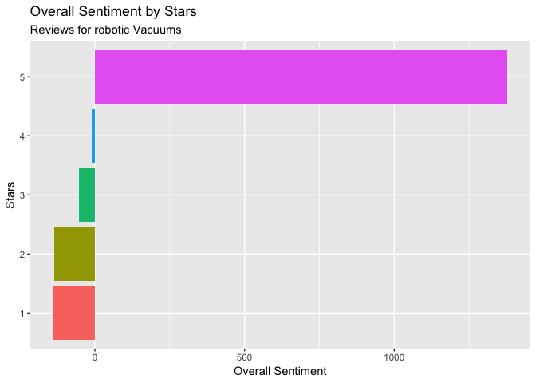

```r
sentiment_stars <- tidy_review %>%
  inner_join(get_sentiments("bing")) %>%
  count(Stars, sentiment) %>%
  spread(sentiment, n) %>%
  mutate(
    overall_sentiment = positive - negative,
    Stars = fct_reorder(as.factor(Stars), overall_sentiment)
  )
## Joining, by = "word"

ggplot(sentiment_stars, aes(Stars, overall_sentiment, fill = as.factor(Stars))) +
  geom_col(show.legend = FALSE) +
  coord_flip() +
  labs(
    title = "Overall Sentiment by Stars",
    subtitle = "Reviews for robotic Vacuums",
    x = "Stars",
    y = "Overall Sentiment"
  )
```

## Practicing reshaping data

### Exercise

The `spread()` verb allows us to quickly reshape or stack and transpose our data, making it easier to `mutate()`.

### Instructions

- Append `tidy_twitter` to the NRC sentiment dictionary.
- Count by complaint label and sentiment.
- Spread the sentiment and count columns.

### script.R

```r
tidy_twitter %>%
  # Appentd the NRC sentiment dictionary
  inner_join(get_sentiments("nrc")) %>%
  # Count by complaint label and sentiment
  count(complaint_label, sentiment) %>%
  # Spread the sentiment and count columns
  spread(sentiment, n)
## Joining, by = "word"
## # A tibble: 2 x 11
##   complaint_label anger anticipation disgust  fear   joy negative positive
##   <chr>           <int>        <int>   <int> <int> <int>    <int>    <int>
## 1 Complaint         559          730     439   552   372     1272     1392
## 2 Non-Complaint     597         1394     441   805  1108     1475     3023
## # … with 3 more variables: sadness <int>, surprise <int>, trust <int>
```

## Practicing with grouped summaries

### Exercise

We can use `spread()` in associtation with the output of grouped summaries as well.

### Instructions

- Append `tidy_twitter` to the afinn sentiment dictionary.
- Group by both complaint label and whether or not the user is verified.
- Summarize the data to create a new column, `aggregate_score`, which contains the sum of `score`.
- Spread the `complaint_label` and `aggregate_score` columns.

### script.R

```r
tidy_twitter %>%
  # Append the afinn sentiment dictionary
  inner_join(get_sentiments("afinn")) %>%
  # Group by both complaint label and whether or not the user is verified
  group_by(complaint_label, usr_verified) %>%
  # Summarise the data with an aggregate_score = sum(score)
  summarise(aggregate_score = sum(score)) %>%
  # Spread the complaint_label and aggregate_score columns
  spread(complaint_label, aggregate_score) %>%
  mutate(overall_sentiment = Complaint + `Non-Complaint`)
## Joining, by = "word"
## # A tibble: 2 x 4
##   usr_verified Complaint `Non-Complaint` overall_sentiment
##   <lgl>            <int>           <int>             <int>
## 1 FALSE            -1556            2348               792
## 2 TRUE               -12              63                51
```

## Visualizing sentiment by complaint type

### Exercise

Now let’s see whether or not complaints really are more negative, on average.

### Instructions 1/2

- Append `tidy_twitter` to the bing sentiment dictionary.
- Count by complaint label and sentiment.
- Spread the sentiment and count columns.
- Add a new column, `overall_sentiment`, as `positive - negative`.

### script.R 1/2

```r
sentiment_twitter <- tidy_twitter %>%
  # Append the bing sentiment dictionary
  inner_join(get_sentiments("bing")) %>%
  # Count by complaint label and sentiment
  count(complaint_label, sentiment) %>%
  # Spread the sentiment and count columns
  spread(sentiment, n) %>%
  # Compute overall_sentiment = positive - negative
  mutate(overall_sentiment = positive - negative)
## Joining, by = "word"
```

### Instuctoins 2/2

- Create a bar plot of overall sentiment by complaint label, colored by complaint level (as a factor).
- Title the plot “Overall Sentiment by Complaint Type,” with the subtitle “Airline Twitter Data”.

### script.R 2/2

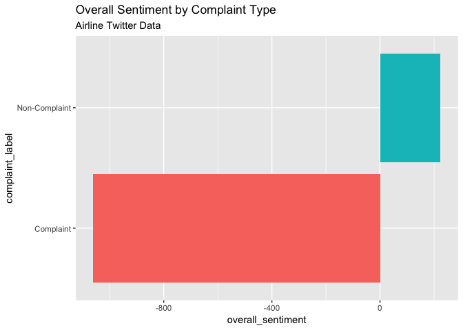

```r
# Create a bar plot out of overall sentiment by complaint level, colored by a complaint label factor
ggplot(sentiment_twitter, aes(complaint_label, overall_sentiment, fill = as.factor(complaint_label))) +
  geom_col(show.legend = FALSE) +
  coord_flip() +
  # Title the plot "Overall Sentiment by Complaint Type," with an "Airline Twitter Data" subtitle
  labs(title = "Overall Sentiment by Complaint Type",
       subtitle = "Airline Twitter Data")
```